# Assignment 5: GAM

Víctor Villegas, Roger Llorenç, Luis Sierra

2024-03-26

```r
# Clears plots
while (dev.cur() != 1) {
  dev.off()
}
# Clears global environment
rm(list = ls())

set.seed(1234)
```

### Initial remark: double-blind trials

(Taken from [this](https://www.news-medical.net/health/What-is-a-Double-Blind-Trial.aspx) website)

In double-blind trials, the treatment patients have is unknown to both patients and doctors until after the study is concluded. This differs from other types of trials, such as simple blind trials where only the patients are unaware of the treatment they are receiving, whereas the doctors know.

Double-blind trials are a form of randomized trials and can be ‘upgraded’ to triple-blind trials, in which the statisticians or data clean-up personnel are also blind to treatments.

To be effective, it is generally recommended that double-blind trials include around 100-300 people. If treatments are highly effective, smaller numbers can be used but if only 30 or so patients are enrolled the study is unlikely to be beneficial.

The assignment of patients into treatments is typically done by computers, where the computer assigns each patient a code number and treatment group. The doctor and patients only know the code number to avoid bias, hence allowing the study to be double-blind.

## GAMs for hirsutism data

In this report we’ll explore several GAM models (including semi-parametric models) explaining `FGm12` as a function of the variables that were measured at the beginning of the clinical trial and Treatment (treated as factor, which can by used as value of parameter by in function `s()`).

One of the advantages of GAM models is that they can overcome the curse of dimensionality.

Then we use functions `summary`, `plot`, `vis.gam` and `gam.check` to get an insight into the fitted models.

To do this, we will be using the following variables:

*Note: The term “baseline“ means that these variables were measured at the beginning of the clinical trial*

```r
library(mgcv)
```

```r
library(ggplot2)
library(car)
# data separated by tab, fill in missing values
hirsutism <- read.table("hirsutism.dat", header=T, sep="\t",fill=TRUE)
hirsutism <- na.omit(hirsutism)
# we're using the variable Treatment as a categorical predictor
hirsutism$Treatment <- as.factor(hirsutism$Treatment)

attach(hirsutism)
summary(hirsutism)
```

```
##  Treatment      FGm0            FGm3             FGm6            FGm12
##  0:22      Min.   :14.57   Min.   : 4.381   Min.   : 1.786   Min.   :-1.163
##  1:22      1st Qu.:16.40   1st Qu.: 9.587   1st Qu.: 7.539   1st Qu.: 5.566
##  2:22      Median :17.70   Median :12.643   Median :10.286   Median : 8.069
##  3:25      Mean   :18.67   Mean   :13.129   Mean   :10.940   Mean   : 9.053
##            3rd Qu.:20.27   3rd Qu.:16.219   3rd Qu.:14.285   3rd Qu.:12.402
##            Max.   :28.36   Max.   :25.637   Max.   :23.411   Max.   :22.759
##     SysPres         DiaPres          weight           height
##  Min.   : 88.0   Min.   :46.00   Min.   : 41.00   Min.   :1.480
##  1st Qu.:110.0   1st Qu.:65.00   1st Qu.: 57.00   1st Qu.:1.580
##  Median :115.0   Median :70.00   Median : 64.00   Median :1.610
##  Mean   :115.9   Mean   :70.04   Mean   : 68.06   Mean   :1.613
##  3rd Qu.:120.0   3rd Qu.:75.00   3rd Qu.: 74.50   3rd Qu.:1.650
##  Max.   :162.0   Max.   :95.00   Max.   :113.00   Max.   :1.800
```

### 0. Linear additive model

```r
gam_0 <- gam(FGm12 ~
             (FGm0) + Treatment + (SysPres) +
             (DiaPres) + (weight) + (height),
             data = hirsutism)
summary(gam_0)
```

```
##
## Family: gaussian
## Link function: identity
##
## Formula:
## FGm12 ~ (FGm0) + Treatment + (SysPres) + (DiaPres) + (weight) +
##     (height)
##
## Parametric coefficients:
##             Estimate Std. Error t value Pr(>|t|)
## (Intercept) 19.49686   14.85245   1.313 0.192945
## FGm0         0.59983    0.16862   3.557 0.000626 ***
## Treatment1  -4.33022    1.48110  -2.924 0.004471 **
## Treatment2  -4.31441    1.49589  -2.884 0.005012 **
## Treatment3  -3.94666    1.44364  -2.734 0.007668 **
## SysPres     -0.07570    0.05194  -1.458 0.148787
## DiaPres      0.03525    0.07115   0.495 0.621652
## weight       0.02768    0.04425   0.626 0.533308
## height      -8.71024    9.08570  -0.959 0.340540
## ---
## Signif. codes:  0 '***' 0.001 '**' 0.01 '*' 0.05 '.' 0.1 ' ' 1
##
##
## R-sq.(adj) =   0.17   Deviance explained = 24.4%
## GCV = 25.139  Scale est. = 22.653    n = 91
```

- **p-value:** None of the following are statistically significant since their p-value is too high: `SysPres`, `weight`, `height`.
- **R-squared (adjusted):** The model explains around 17% of the variance in `FGm12`.
- **Deviance explained:** 24.4%.

  The previous two values lead us to conclude that the explanatory potential of this model is limited but not null.
- **Number of observations:** notice that the `gam` functions removes the 8 observations with missing values. So `n=91`.
- **Visualization:**

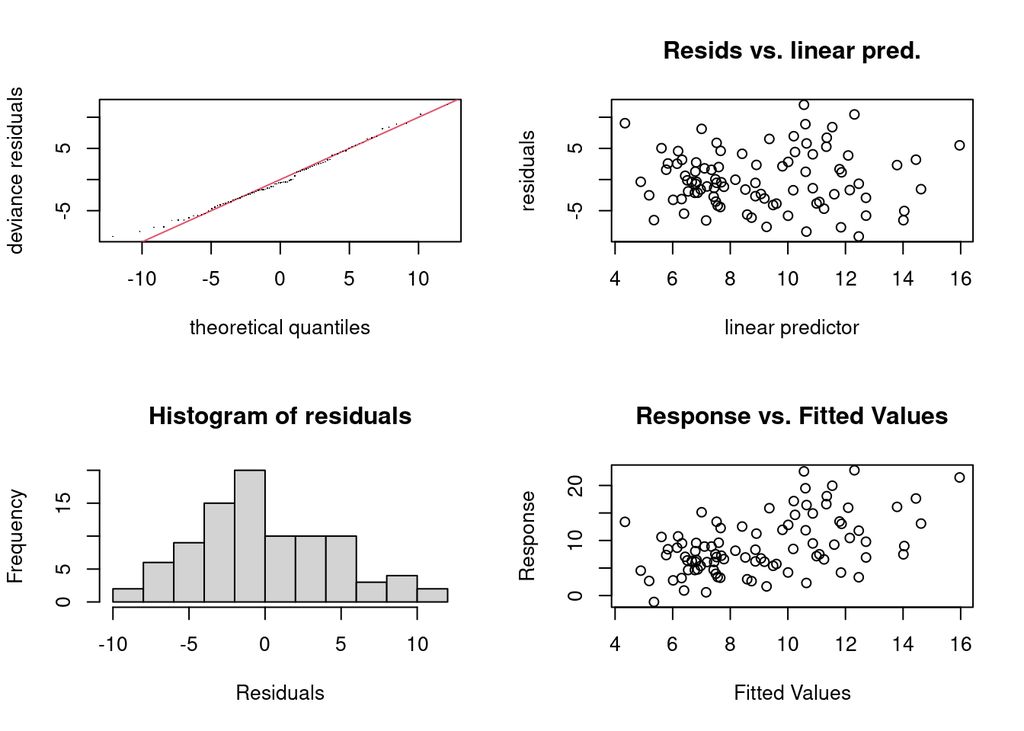

  ```
  ##
  ## Method: GCV   Optimizer: magic
  ## Model required no smoothing parameter selectionModel rank =  9 / 9
  ```

  ```r
  gam.check(gam_0)
  ```

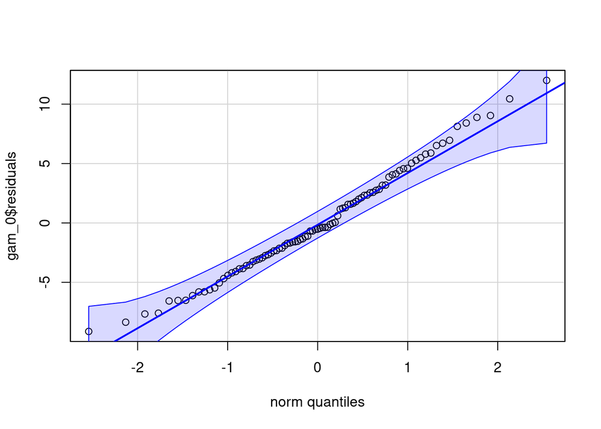

  ```r
  qqPlot(gam_0$residuals, id=FALSE)
  ```

### 1. Smoothing

- Variable `Treatment` is a factor, so it doesn’t have to be smoothed.

```r
gam_1 <- gam(FGm12 ~
             s(FGm0) + Treatment + s(SysPres) +
             s(DiaPres) + s(weight) + s(height),
             data = hirsutism)
summary(gam_1)
```

```
##
## Family: gaussian
## Link function: identity
##
## Formula:
## FGm12 ~ s(FGm0) + Treatment + s(SysPres) + s(DiaPres) + s(weight) +
##     s(height)
##
## Parametric coefficients:
##             Estimate Std. Error t value Pr(>|t|)
## (Intercept)   12.477      0.985  12.667  < 2e-16 ***
## Treatment1    -4.868      1.405  -3.465 0.000876 ***
## Treatment2    -4.576      1.418  -3.227 0.001847 **
## Treatment3    -4.154      1.383  -3.005 0.003601 **
## ---
## Signif. codes:  0 '***' 0.001 '**' 0.01 '*' 0.05 '.' 0.1 ' ' 1
##
## Approximate significance of smooth terms:
##              edf Ref.df     F p-value
## s(FGm0)    6.114  7.238 3.798 0.00143 **
## s(SysPres) 1.000  1.000 3.015 0.08653 .
## s(DiaPres) 1.956  2.464 1.191 0.40264
## s(weight)  1.000  1.000 1.146 0.28770
## s(height)  1.000  1.000 1.454 0.23159
## ---
## Signif. codes:  0 '***' 0.001 '**' 0.01 '*' 0.05 '.' 0.1 ' ' 1
##
## R-sq.(adj) =  0.288   Deviance explained = 39.9%
## GCV =  23.31  Scale est. = 19.45     n = 91
```

- **p-value:** the meaning of the relevant values don’t change.
- **R-squared (adjusted):** The model explains around 28.8% of the variance in `FGm12`.
- **Deviance explained:** 39.9%.

  The explanatory potential of the model has improved a considerable amount with respect to the previous one.
- **Number of observations:** notice that the `gam` functions removes the 8 observations with missing values. So `n=91`.
- **Visualization:**

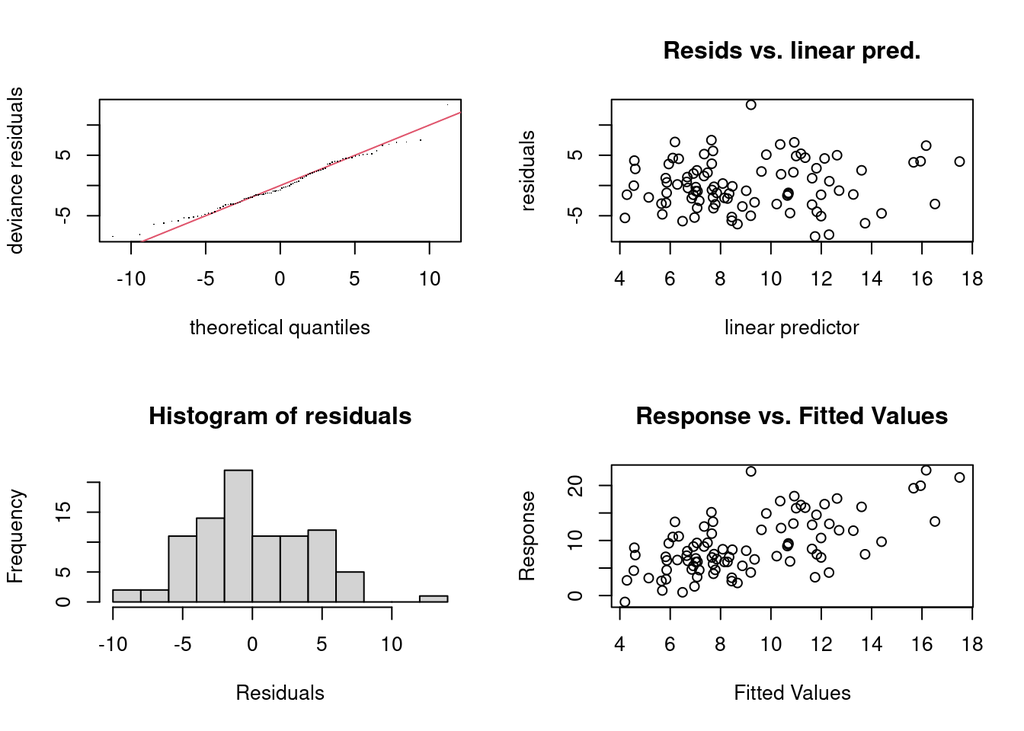

  ```
  ##
  ## Method: GCV   Optimizer: magic
  ## Smoothing parameter selection converged after 22 iterations.
  ## The RMS GCV score gradient at convergence was 8.714651e-07 .
  ## The Hessian was positive definite.
  ## Model rank =  49 / 49
  ##
  ## Basis dimension (k) checking results. Low p-value (k-index<1) may
  ## indicate that k is too low, especially if edf is close to k'.
  ##
  ##              k'  edf k-index p-value
  ## s(FGm0)    9.00 6.11    1.12   0.860
  ## s(SysPres) 9.00 1.00    1.09   0.760
  ## s(DiaPres) 9.00 1.96    1.06   0.690
  ## s(weight)  9.00 1.00    1.10   0.810
  ## s(height)  9.00 1.00    0.87   0.085 .
  ## ---
  ## Signif. codes:  0 '***' 0.001 '**' 0.01 '*' 0.05 '.' 0.1 ' ' 1
  ```

  ```r
  gam.check(gam_1)
  ```

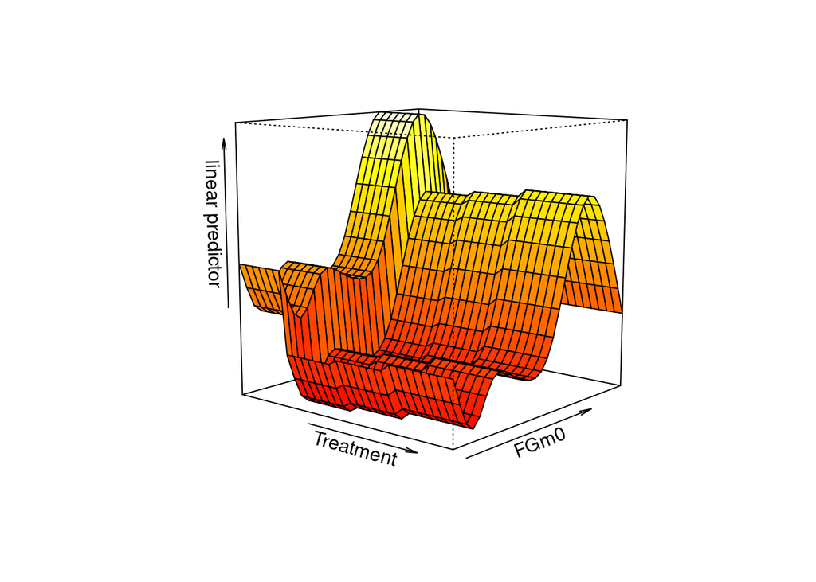

  ```r
  vis.gam(gam_1,se=0,theta =40, phi = 10, d=4,nticks=3)
  ```

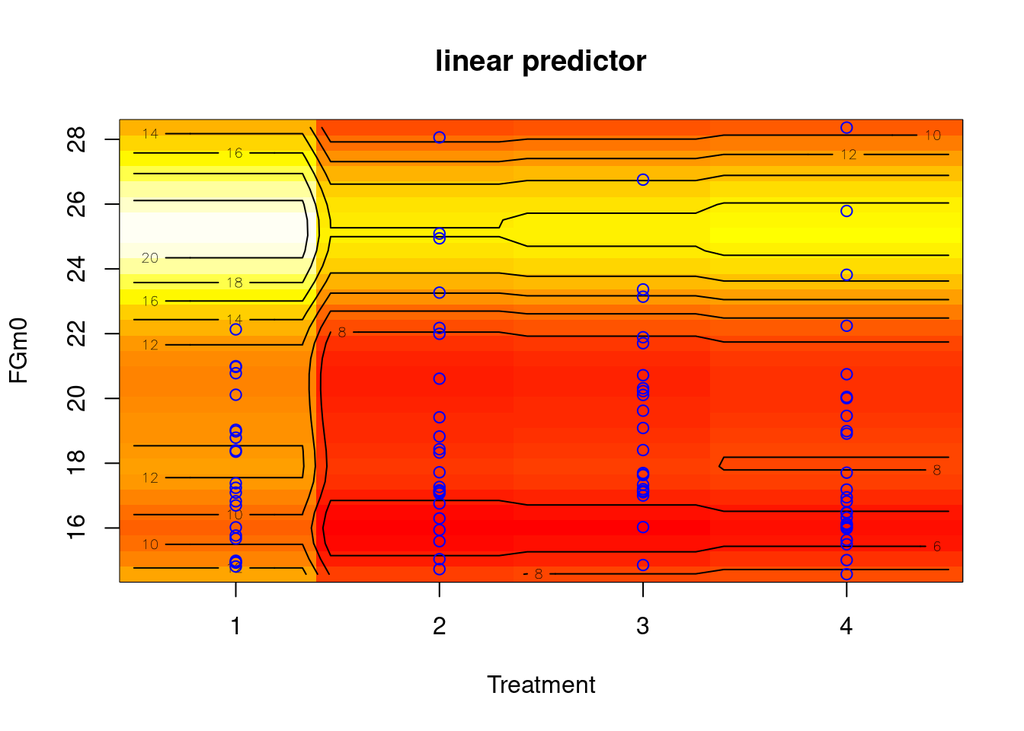

  ```r
  vis.gam(gam_1,se=0,plot.type="contour",contour.col=1)
  points(Treatment,FGm0,col="blue")
  ```

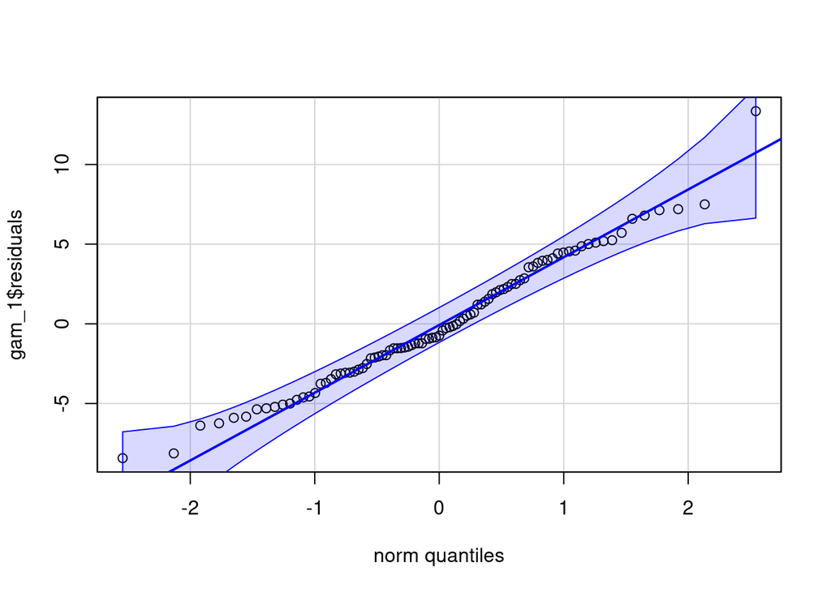

  ```r
  qqPlot(gam_1$residuals, id=FALSE)
  ```

  From the quantile-quantile plot, we may observe some evidence for heavy tails, which may indicate that the assumption of normality is too strong.

  **Individual effects** of each explanatory variable:

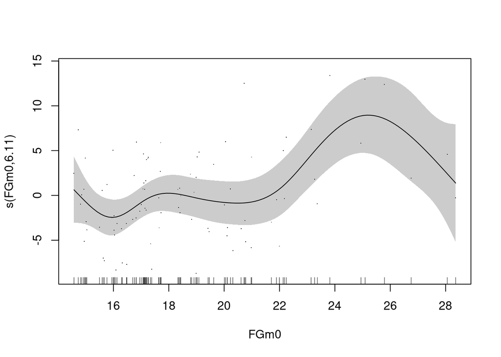

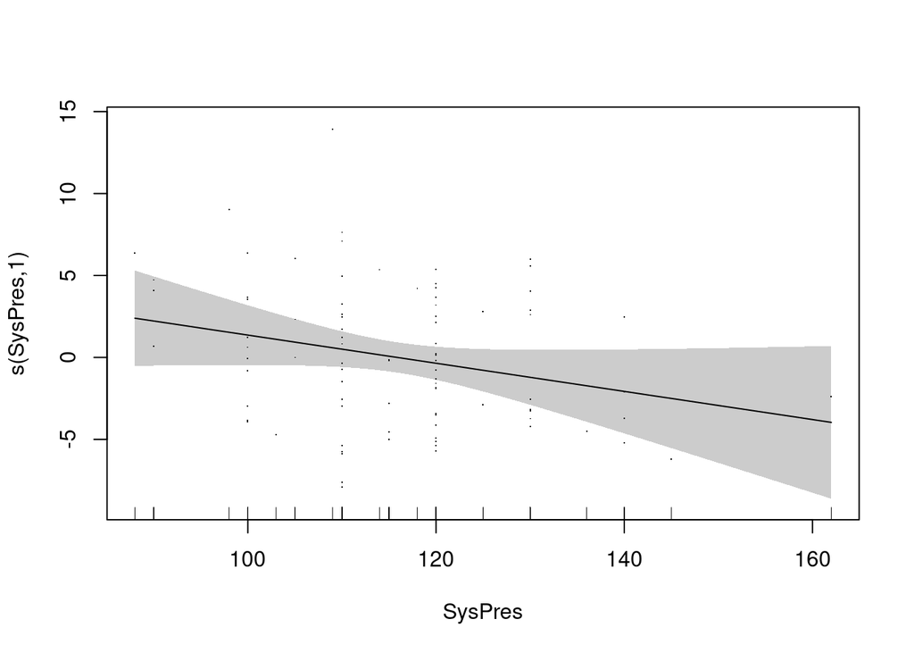

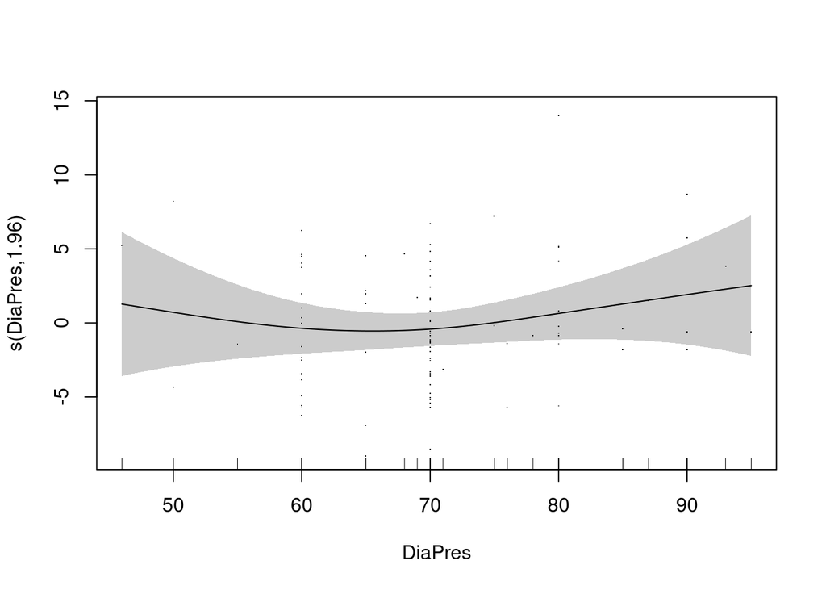

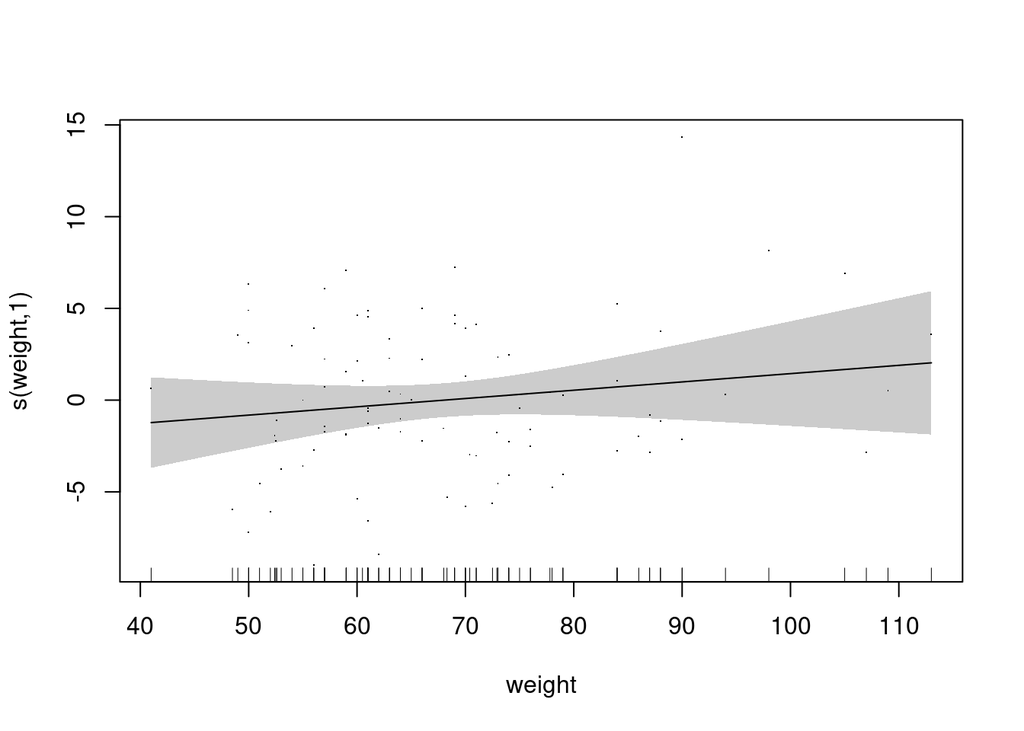

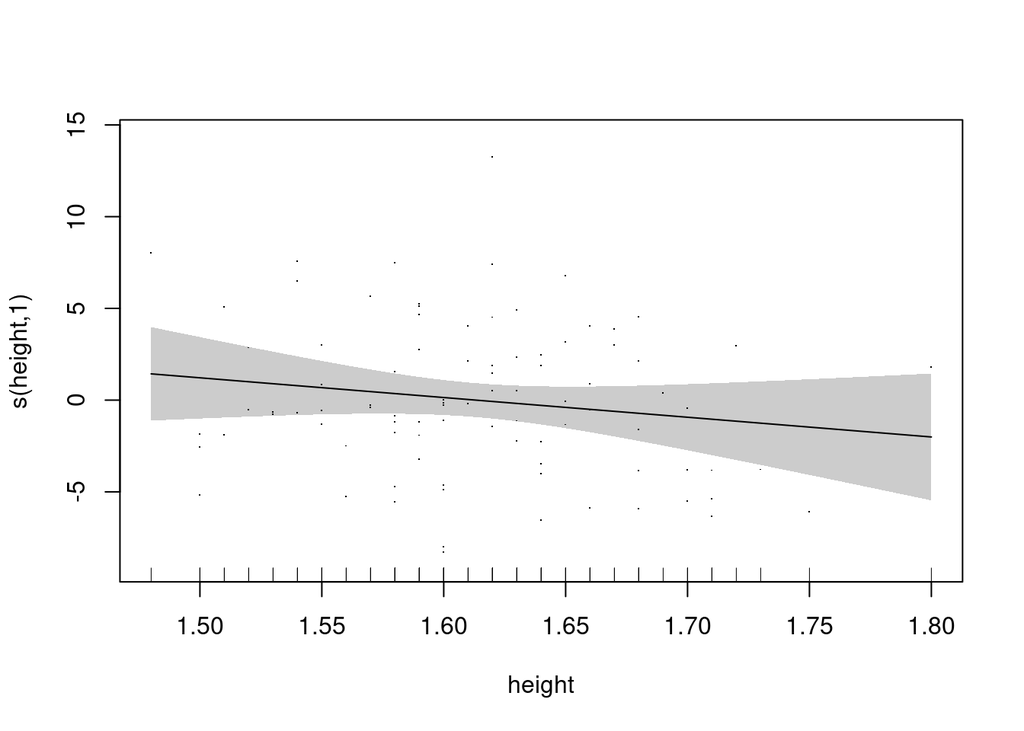

  ```r
  plot(gam_1, residuals = TRUE, shade=TRUE, seWithMean=TRUE)
  ```

### 2. Joining variables

- We fit jointly weight and height by taking the tensor product as `te(weight,height)` in order to capture the physical effect.
- We fit jointly systolic and diastolic blood pressure by `te(SysPres,DiaPres)` in order to capture the physical effect.

```r
gam_2 <- gam(FGm12 ~
             s(FGm0) + Treatment
             + te(SysPres,DiaPres) + te(weight,height),
             data = hirsutism)
summary(gam_2)
```

```
##
## Family: gaussian
## Link function: identity
##
## Formula:
## FGm12 ~ s(FGm0) + Treatment + te(SysPres, DiaPres) + te(weight,
##     height)
##
## Parametric coefficients:
##             Estimate Std. Error t value Pr(>|t|)
## (Intercept)  12.5280     0.9721  12.888  < 2e-16 ***
## Treatment1   -5.0660     1.3952  -3.631 0.000521 ***
## Treatment2   -4.4030     1.4012  -3.142 0.002422 **
## Treatment3   -4.3167     1.3777  -3.133 0.002488 **
## ---
## Signif. codes:  0 '***' 0.001 '**' 0.01 '*' 0.05 '.' 0.1 ' ' 1
##
## Approximate significance of smooth terms:
##                       edf Ref.df     F  p-value
## s(FGm0)             6.357  7.428 4.007 0.000699 ***
## te(SysPres,DiaPres) 4.031  4.660 1.481 0.230636
## te(weight,height)   3.570  3.987 1.013 0.403700
## ---
## Signif. codes:  0 '***' 0.001 '**' 0.01 '*' 0.05 '.' 0.1 ' ' 1
##
## R-sq.(adj) =  0.316   Deviance explained = 44.5%
## GCV = 23.279  Scale est. = 18.685    n = 91
```

- **p-value:** There hasn’t been an improvement, the non-significant variables remain so.
- **R-squared (adjusted):** 31.6%
- **Deviance explained:** It has increased to 44.5%.

  The increase of these two last values means an improvement in the explanatory potential of the model, that is, this model is better than the previous one.
- **Visualization:**

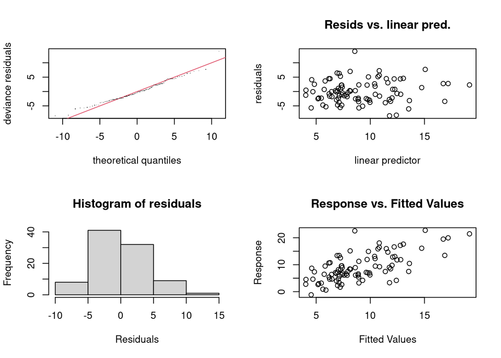

  ```
  ##
  ## Method: GCV   Optimizer: magic
  ## Smoothing parameter selection converged after 30 iterations.
  ## The RMS GCV score gradient at convergence was 1.10955e-06 .
  ## The Hessian was positive definite.
  ## Model rank =  61 / 61
  ##
  ## Basis dimension (k) checking results. Low p-value (k-index<1) may
  ## indicate that k is too low, especially if edf is close to k'.
  ##
  ##                        k'   edf k-index p-value
  ## s(FGm0)              9.00  6.36     1.1    0.69
  ## te(SysPres,DiaPres) 24.00  4.03     1.2    0.95
  ## te(weight,height)   24.00  3.57     0.9    0.14
  ```

  ```r
  gam.check(gam_2)
  ```

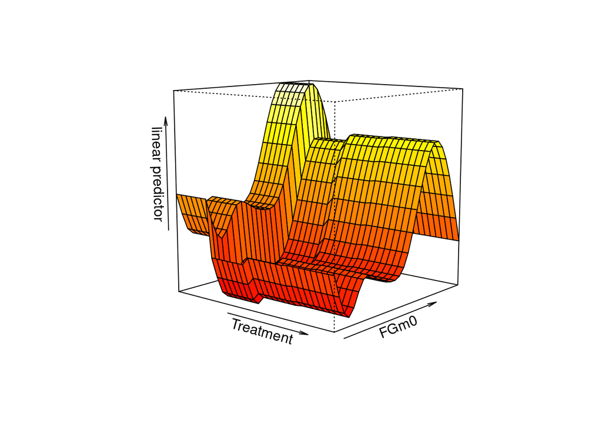

  ```r
  vis.gam(gam_2,se=0,theta =40, phi = 10, d=4,nticks=3)
  ```

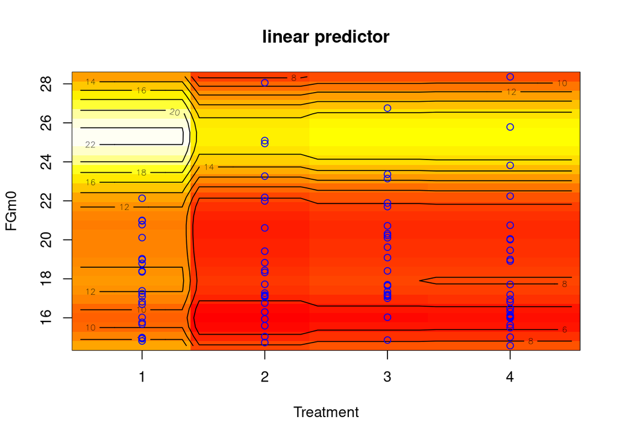

  ```r
  vis.gam(gam_2,se=0,plot.type="contour",contour.col=1)
  points(Treatment,FGm0,col="blue")
  ```

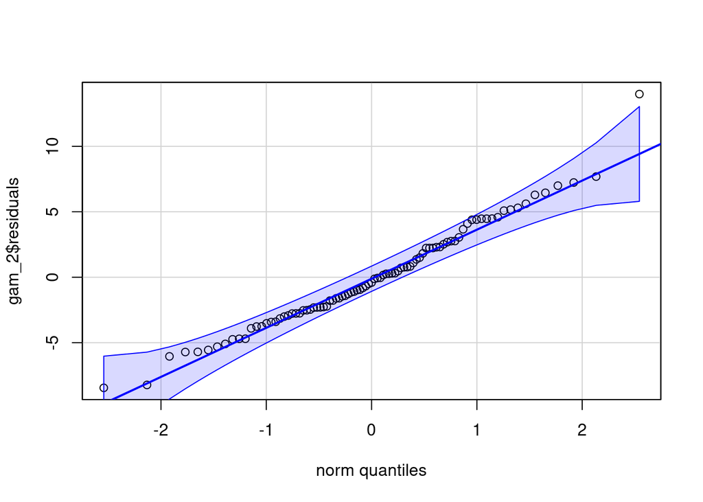

  ```r
  qqPlot(gam_2$residuals, id=FALSE)
  ```

  **Individual effects** of each explanatory variable:

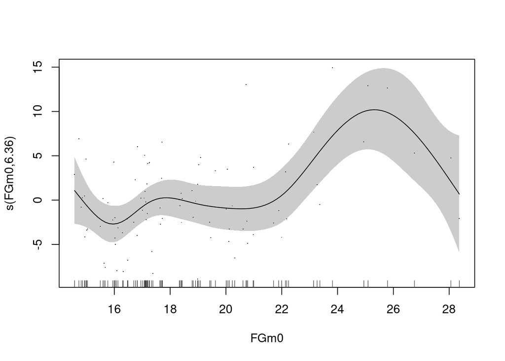

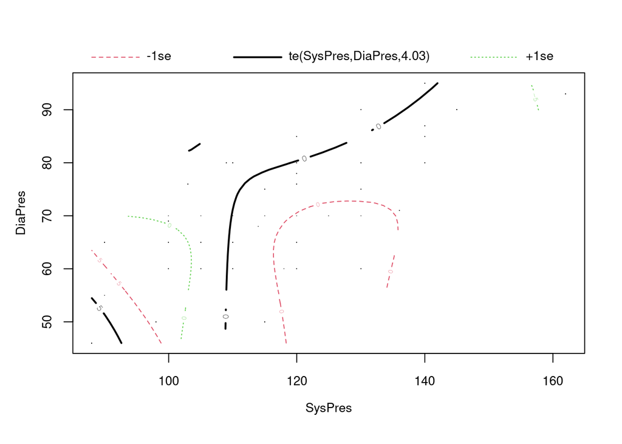

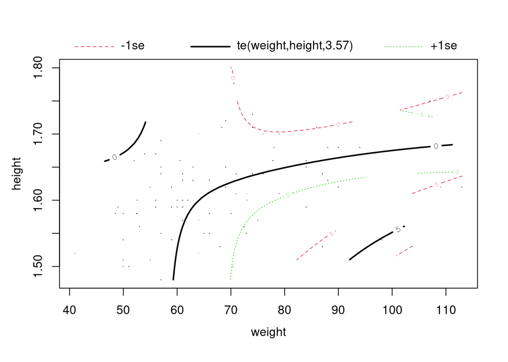

  ```r
  plot(gam_2, residuals = TRUE, shade=TRUE, seWithMean=TRUE)
  ```

  **Joint effects** of a pair of variables

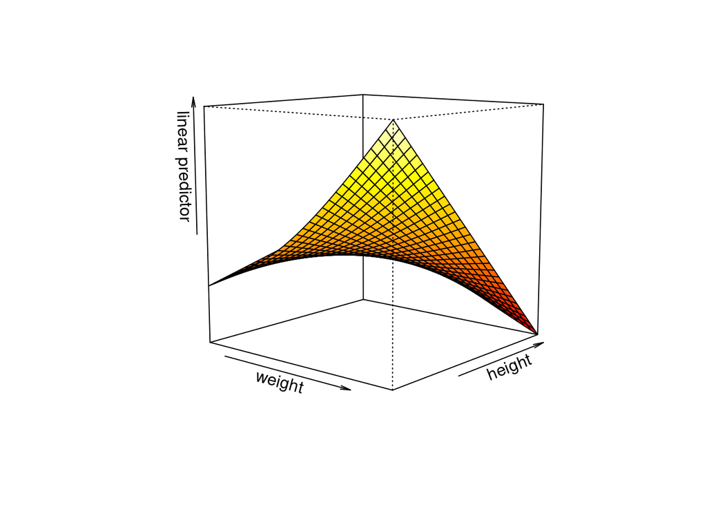

  ```r
  vis.gam(gam_2, view=c("weight","height"), plot.type = "persp", theta=40, phi=10,d=4,nticks=3)
  ```

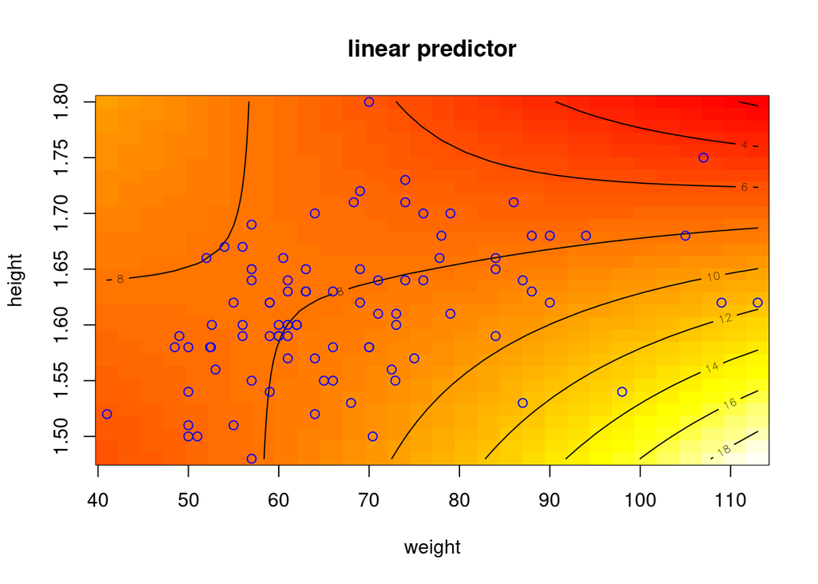

  ```r
  vis.gam(gam_2, view=c("weight","height"), plot.type = "contour",contour.col=1)
  points(weight,height,col="blue")
  ```

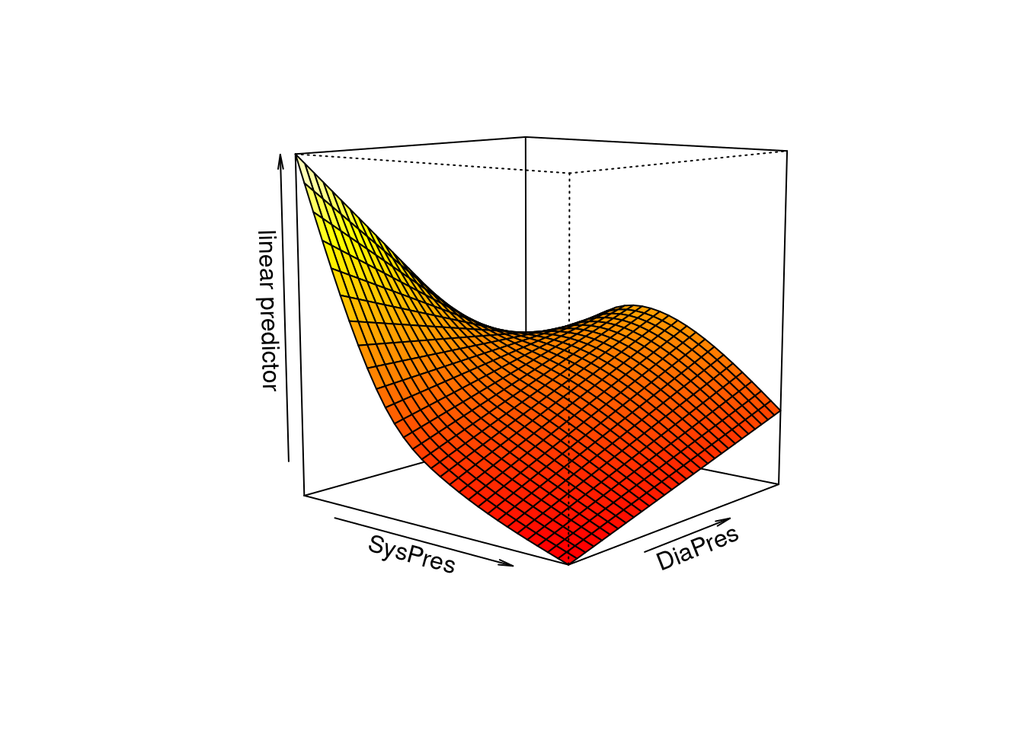

  ```r
  vis.gam(gam_2, view=c("SysPres","DiaPres"), plot.type = "persp", theta=40, phi=10,d=4,nticks=3)
  ```

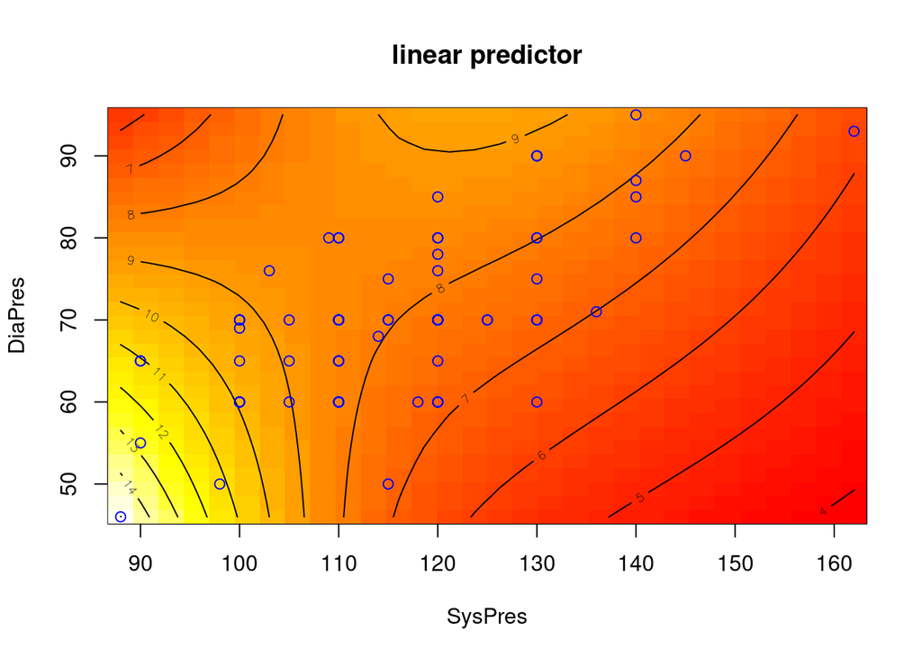

  ```r
  vis.gam(gam_2, view=c("SysPres","DiaPres"), plot.type = "contour",contour.col=1)
  points(SysPres,DiaPres,col="blue")
  ```

**Refinements** that can be done are:

- Certain variables could be removed from the model because the corresponding `p-values` are large.

### 3. Refining (2)

Now we remove non-significant variables from the model one at a time, in decreasing order of p-values, until all variables are significant.

```r
gam_3a <- gam(FGm12 ~
             s(FGm0) + Treatment
             + te(SysPres,DiaPres),
             data = hirsutism)
summary(gam_3a)
```

```
##
## Family: gaussian
## Link function: identity
##
## Formula:
## FGm12 ~ s(FGm0) + Treatment + te(SysPres, DiaPres)
##
## Parametric coefficients:
##             Estimate Std. Error t value Pr(>|t|)
## (Intercept)  12.3097     0.9688  12.706  < 2e-16 ***
## Treatment1   -5.0527     1.3938  -3.625 0.000518 ***
## Treatment2   -4.2882     1.3969  -3.070 0.002962 **
## Treatment3   -3.6348     1.3221  -2.749 0.007445 **
## ---
## Signif. codes:  0 '***' 0.001 '**' 0.01 '*' 0.05 '.' 0.1 ' ' 1
##
## Approximate significance of smooth terms:
##                       edf Ref.df     F p-value
## s(FGm0)             6.372  7.485 3.816 0.00134 **
## te(SysPres,DiaPres) 4.007  4.650 1.505 0.18845
## ---
## Signif. codes:  0 '***' 0.001 '**' 0.01 '*' 0.05 '.' 0.1 ' ' 1
##
## R-sq.(adj) =  0.305   Deviance explained = 40.8%
## GCV = 22.546  Scale est. = 18.984    n = 91
```

```r
gam_3 <- gam(FGm12 ~
             s(FGm0) + (Treatment),
             data = hirsutism)
summary(gam_3)
```

```
##
## Family: gaussian
## Link function: identity
##
## Formula:
## FGm12 ~ s(FGm0) + (Treatment)
##
## Parametric coefficients:
##             Estimate Std. Error t value Pr(>|t|)
## (Intercept)  12.3681     0.9808  12.610  < 2e-16 ***
## Treatment1   -5.0794     1.3986  -3.632 0.000492 ***
## Treatment2   -4.5832     1.3969  -3.281 0.001526 **
## Treatment3   -3.5641     1.3483  -2.643 0.009847 **
## ---
## Signif. codes:  0 '***' 0.001 '**' 0.01 '*' 0.05 '.' 0.1 ' ' 1
##
## Approximate significance of smooth terms:
##           edf Ref.df     F p-value
## s(FGm0) 5.763  6.892 3.999 0.00102 **
## ---
## Signif. codes:  0 '***' 0.001 '**' 0.01 '*' 0.05 '.' 0.1 ' ' 1
##
## R-sq.(adj) =  0.259   Deviance explained = 33.1%
## GCV = 22.667  Scale est. = 20.235    n = 91
```

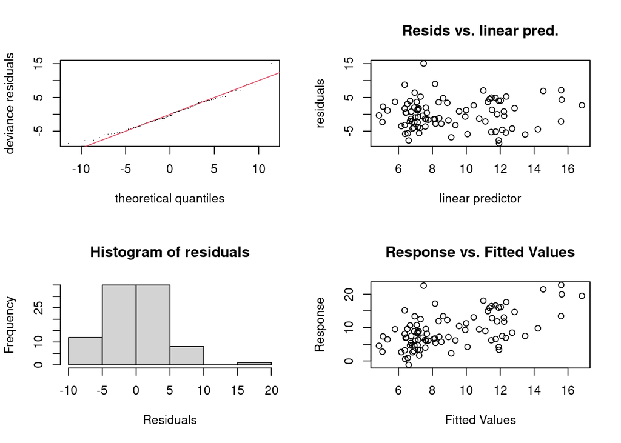

  ```
  ##
  ## Method: GCV   Optimizer: magic
  ## Smoothing parameter selection converged after 6 iterations.
  ## The RMS GCV score gradient at convergence was 0.0001388711 .
  ## The Hessian was positive definite.
  ## Model rank =  13 / 13
  ##
  ## Basis dimension (k) checking results. Low p-value (k-index<1) may
  ## indicate that k is too low, especially if edf is close to k'.
  ##
  ##           k'  edf k-index p-value
  ## s(FGm0) 9.00 5.76    1.06    0.65
  ```

  ```r
  gam.check(gam_3)
  ```

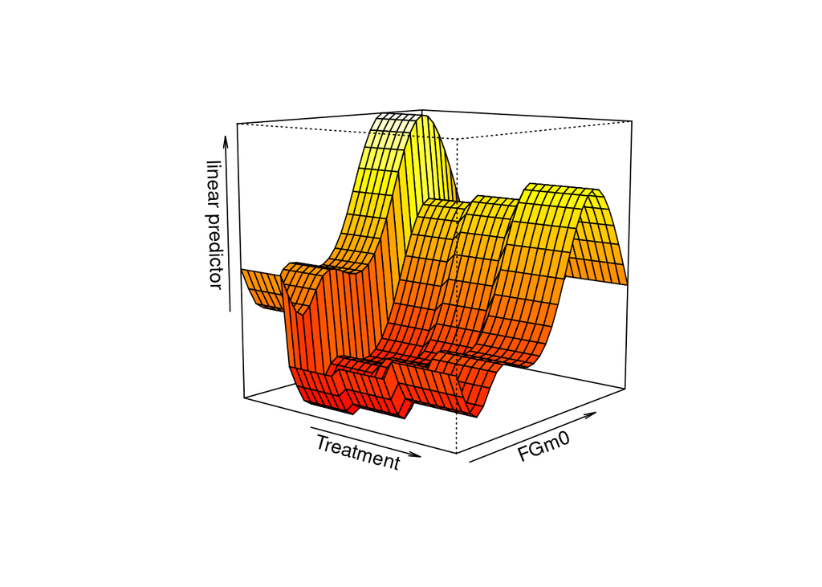

  ```r
  vis.gam(gam_3, se=0, theta = 40, phi = 10, d=4,nticks=3)
  ```

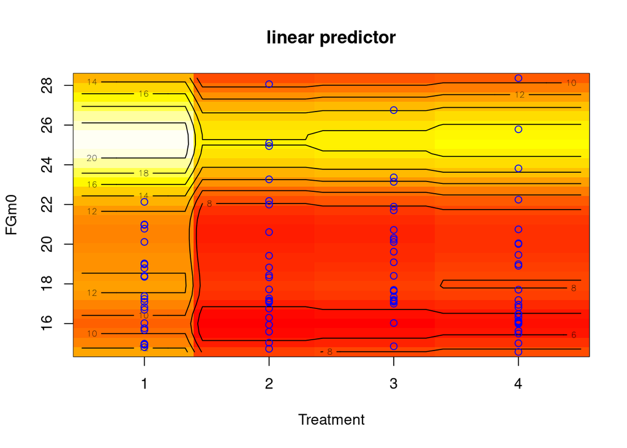

  ```r
  vis.gam(gam_1, se=0, plot.type="contour",contour.col=1)
  points(Treatment,FGm0,col="blue")
  ```

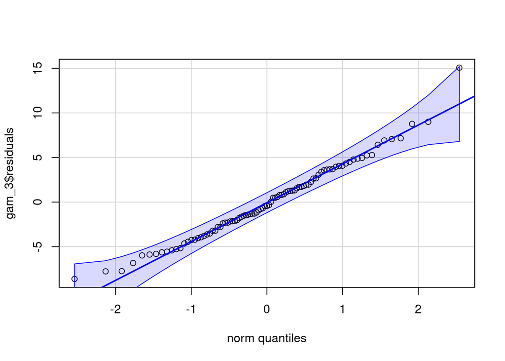

  ```r
  qqPlot(gam_3$residuals, id=FALSE)
  ```

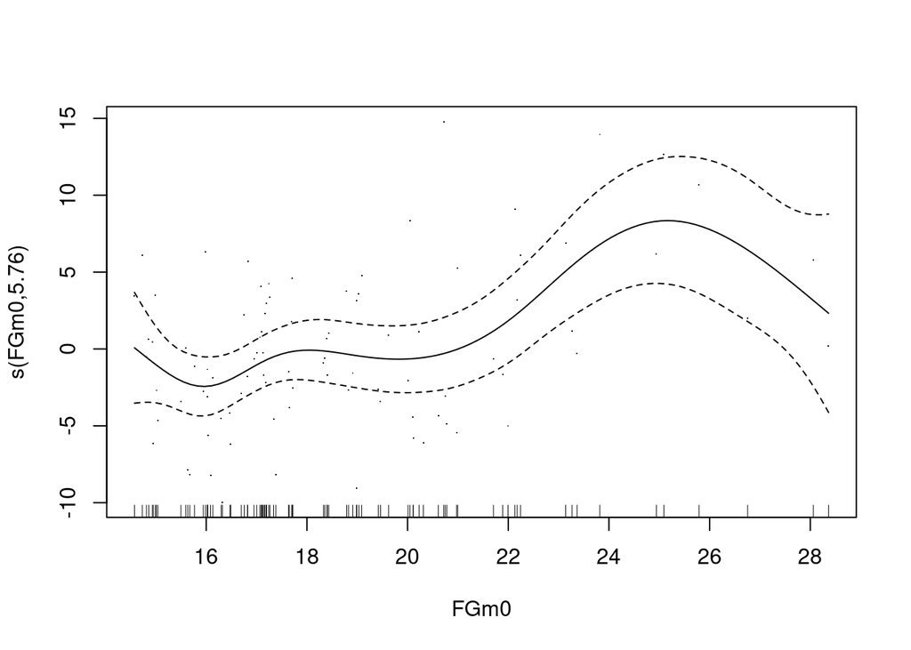

  ```r
  plot(gam_3, residuals = TRUE, seWithMean=TRUE)
  ```

## 4. `Treatment` as a parameter of `s()`

Now we separate the continuous variables according to the treatment group.

```r
gam_1b <- gam(FGm12 ~
             s(FGm0, by=Treatment) + s(SysPres, by=Treatment) +
             s(DiaPres, by=Treatment) + s(weight, by=Treatment) + s(height, by=Treatment),
             data = hirsutism)
summary(gam_1b)
```

```
##
## Family: gaussian
## Link function: identity
##
## Formula:
## FGm12 ~ s(FGm0, by = Treatment) + s(SysPres, by = Treatment) +
##     s(DiaPres, by = Treatment) + s(weight, by = Treatment) +
##     s(height, by = Treatment)
##
## Parametric coefficients:
##             Estimate Std. Error t value Pr(>|t|)
## (Intercept)   7.5764     0.3142   24.11 1.32e-14 ***
## ---
## Signif. codes:  0 '***' 0.001 '**' 0.01 '*' 0.05 '.' 0.1 ' ' 1
##
## Approximate significance of smooth terms:
##                         edf Ref.df       F  p-value
## s(FGm0):Treatment0    7.948  7.962  25.788  < 2e-16 ***
## s(FGm0):Treatment1    8.694  8.889  32.609  < 2e-16 ***
## s(FGm0):Treatment2    1.000  1.000   0.564 0.463070
## s(FGm0):Treatment3    1.000  1.000 260.291  < 2e-16 ***
## s(SysPres):Treatment0 1.000  1.000   0.107 0.747020
## s(SysPres):Treatment1 1.000  1.000  19.500 0.000377 ***
## s(SysPres):Treatment2 4.458  4.929  18.004 6.52e-06 ***
## s(SysPres):Treatment3 7.835  7.918  16.471 2.39e-06 ***
## s(DiaPres):Treatment0 4.372  4.458   4.258 0.088535 .
## s(DiaPres):Treatment1 4.790  5.442   3.164 0.025008 *
## s(DiaPres):Treatment2 1.092  1.144  14.564 0.003574 **
## s(DiaPres):Treatment3 5.816  6.017  26.818  < 2e-16 ***
## s(weight):Treatment0  1.000  1.000   1.670 0.213520
## s(weight):Treatment1  1.000  1.000  29.318 4.52e-05 ***
## s(weight):Treatment2  8.545  8.742  21.293  < 2e-16 ***
## s(weight):Treatment3  1.000  1.000  48.935 1.04e-06 ***
## s(height):Treatment0  6.349  6.558  27.461 8.08e-07 ***
## s(height):Treatment1  1.342  1.544   5.964 0.020313 *
## s(height):Treatment2  3.726  4.209   2.007 0.157563
## s(height):Treatment3  1.000  1.000 198.946  < 2e-16 ***
## ---
## Signif. codes:  0 '***' 0.001 '**' 0.01 '*' 0.05 '.' 0.1 ' ' 1
##
## Rank: 180/181
## R-sq.(adj) =  0.971   Deviance explained = 99.5%
## GCV = 4.1831  Scale est. = 0.78303   n = 91
```

- **p-value:** almost all variables all relevant.
- **R-squared (adjusted):** 97.1%
- **Deviance explained:** 99.5%.

```r
gam_2b <- gam(FGm12 ~
             s(FGm0, by=Treatment)
             + te(SysPres,DiaPres, by=Treatment) + te(weight,height, by=Treatment),
             data = hirsutism)
summary(gam_2b)
```

```
##
## Family: gaussian
## Link function: identity
##
## Formula:
## FGm12 ~ s(FGm0, by = Treatment) + te(SysPres, DiaPres, by = Treatment) +
##     te(weight, height, by = Treatment)
##
## Parametric coefficients:
##             Estimate Std. Error t value Pr(>|t|)
## (Intercept)   8.9658     0.2963   30.26    0.998
##
## Approximate significance of smooth terms:
##                                   edf Ref.df         F p-value
## s(FGm0):Treatment0              3.567  3.567    11.149 0.21916
## s(FGm0):Treatment1              8.706  8.706  7841.847 0.00984 **
## s(FGm0):Treatment2              1.000  1.000     1.984 0.39308
## s(FGm0):Treatment3              7.260  7.260   166.868 0.06220 .
## te(SysPres,DiaPres):Treatment0  8.438  8.439    56.856 0.10096
## te(SysPres,DiaPres):Treatment1  5.144  5.144    13.593 0.20020
## te(SysPres,DiaPres):Treatment2 11.724 11.724 44961.654 0.00410 **
## te(SysPres,DiaPres):Treatment3  9.884  9.884   152.141 0.05854 .
## te(weight,height):Treatment0    9.991  9.991    19.420 0.17577
## te(weight,height):Treatment1    7.763  7.763    51.454 0.10797
## te(weight,height):Treatment2    8.870  8.870 55157.761 0.00355 **
## te(weight,height):Treatment3    7.653  7.653   132.998 0.06670 .
## ---
## Signif. codes:  0 '***' 0.001 '**' 0.01 '*' 0.05 '.' 0.1 ' ' 1
##
## R-sq.(adj) =      1   Deviance explained =  100%
## GCV = 2.6393  Scale est. = 7.4463e-06  n = 91
```

# ANOVA type tests

```r
anova(gam_3, gam_3a, test="F")
```

```
## Analysis of Deviance Table
##
## Model 1: FGm12 ~ s(FGm0) + (Treatment)
## Model 2: FGm12 ~ s(FGm0) + Treatment + te(SysPres, DiaPres)
##   Resid. Df Resid. Dev    Df Deviance      F Pr(>F)
## 1    80.108     1643.8
## 2    74.866     1454.6 5.242   189.29 1.9022 0.1008
```

```r
# accept null and gam_3 = gam_3a
```

```r
anova(gam_3a, gam_2, test="F")
```

```
## Analysis of Deviance Table
##
## Model 1: FGm12 ~ s(FGm0) + Treatment + te(SysPres, DiaPres)
## Model 2: FGm12 ~ s(FGm0) + Treatment + te(SysPres, DiaPres) + te(weight,
##     height)
##   Resid. Df Resid. Dev     Df Deviance      F Pr(>F)
## 1    74.866     1454.6
## 2    70.925     1364.8 3.9411   89.772 1.2191 0.3105
```

```r
# accept null gam_3a = gam_2
```

```r
anova(gam_3, gam_2, test="F")
```

```
## Analysis of Deviance Table
##
## Model 1: FGm12 ~ s(FGm0) + (Treatment)
## Model 2: FGm12 ~ s(FGm0) + Treatment + te(SysPres, DiaPres) + te(weight,
##     height)
##   Resid. Df Resid. Dev     Df Deviance      F Pr(>F)
## 1    80.108     1643.8
## 2    70.925     1364.8 9.1831   279.06 1.6264 0.1228
```

```r
# accept null gam_3 = gam_2
```

```r
anova(gam_1, gam_2, test="F")
```

```
## Analysis of Deviance Table
##
## Model 1: FGm12 ~ s(FGm0) + Treatment + s(SysPres) + s(DiaPres) + s(weight) +
##     s(height)
## Model 2: FGm12 ~ s(FGm0) + Treatment + te(SysPres, DiaPres) + te(weight,
##     height)
##   Resid. Df Resid. Dev     Df Deviance      F Pr(>F)
## 1    74.297     1476.9
## 2    70.925     1364.8 3.3728   112.08 1.7784 0.1528
```

```r
anova(gam_1, gam_3, test="F")
```

```
## Analysis of Deviance Table
##
## Model 1: FGm12 ~ s(FGm0) + Treatment + s(SysPres) + s(DiaPres) + s(weight) +
##     s(height)
## Model 2: FGm12 ~ s(FGm0) + (Treatment)
##   Resid. Df Resid. Dev      Df Deviance      F Pr(>F)
## 1    74.297     1476.9
## 2    80.108     1643.8 -5.8104  -166.99 1.4776 0.1994
```

```r
anova(gam_3, gam_1b, test="F")
```

```
## Analysis of Deviance Table
##
## Model 1: FGm12 ~ s(FGm0) + (Treatment)
## Model 2: FGm12 ~ s(FGm0, by = Treatment) + s(SysPres, by = Treatment) +
##     s(DiaPres, by = Treatment) + s(weight, by = Treatment) +
##     s(height, by = Treatment)
##   Resid. Df Resid. Dev    Df Deviance      F    Pr(>F)
## 1    80.108    1643.85
## 2    14.187      13.34 65.92   1630.5 31.588 5.999e-09 ***
## ---
## Signif. codes:  0 '***' 0.001 '**' 0.01 '*' 0.05 '.' 0.1 ' ' 1
```

```r
anova(gam_1b, gam_2b, test="F")
```

```
## Analysis of Deviance Table
##
## Model 1: FGm12 ~ s(FGm0, by = Treatment) + s(SysPres, by = Treatment) +
##     s(DiaPres, by = Treatment) + s(weight, by = Treatment) +
##     s(height, by = Treatment)
## Model 2: FGm12 ~ s(FGm0, by = Treatment) + te(SysPres, DiaPres, by = Treatment) +
##     te(weight, height, by = Treatment)
##    Resid. Df Resid. Dev     Df Deviance      F Pr(>F)
## 1 1.4187e+01     13.338
## 2 1.5325e-07      0.000 14.187   13.338 126256      1
```

So model `gam_1b` would be our preferred option.